# Adaptive Gene - Multitrait Association testing with GWAS Summary Statistics (MTaSPUsSet() )

Il-Youp Kwak

2016-04-28

This vignette illustrates the use of MTaSPUsSet test, an adaptive gene-multitrait association testing with GWAS summary statistics.

## Data preparation

We first downloaded GWAS summary statistics of Genetic Investigation of ANthropometric Traits ([GIANT](https://www.broadinstitute.org/collaboration/giant/index.php/GIANT_consortium_data_files)) consortium data. We get the genomic coordinates of SNPs using [SnpTracker](http://www.g3journal.org/content/early/2015/11/17/g3.115.021832) software (hg19 used), and then we mapped SNPs to Genes using [MAGMA](http://ctg.cncr.nl/software/magma) software (build 37 used). We will consider testing a gene named *SAMD11* for example.

Let’s load *SAMD11* data first.

```r
data(SAMD11)
attach(SAMD11)
```

`ZsM` and `PsM` are Z-scores and P-values for GIANT Man data mapped on gene *SAMD11*. (We used [MAGMA](http://ctg.cncr.nl/software/magma) software to map rs ids to genes. )

```r
round(ZsM,3)
```

```
##              BMIm HeightM   HIPm    WCm WeightM   WHRm
## rs4951864  -1.150   0.789 -0.539 -0.706  -0.628 -0.468
## rs12132517  1.372  -0.755  0.690  0.824   0.842  0.279
## rs11240777  1.036   0.878  0.755  1.670   1.254  1.175
```

```r
PsM
```

```
##            BMIm HeightM HIPm   WCm WeightM WHRm
## rs4951864  0.25    0.43 0.59 0.480    0.53 0.64
## rs12132517 0.17    0.45 0.49 0.410    0.40 0.78
## rs11240777 0.30    0.38 0.45 0.095    0.21 0.24
```

Both `ZsM` and `PsM` are 3 by 6 matrix. Row represent SNPs and column represent phenotypes. 3 SNPs are mapped on gene *SAMD11* and 6 number of phenotypes are considered in testing.

`corSNPM` and `corPheM` are correlation among SNPs and Phenotypes respectively for GIANT Man data.

```r
round(corSNPM,2)
```

```
##            rs4951864 rs12132517 rs11240777
## rs4951864       1.00      -0.89      -0.49
## rs12132517     -0.89       1.00       0.44
## rs11240777     -0.49       0.44       1.00
```

```r
round(corPheM,2)
```

```
##        V4    V6    V8   V12  V16   V18
## V4   1.00 -0.02  0.12  0.27 0.56  0.07
## V6  -0.02  1.00  0.00 -0.01 0.08  0.00
## V8   0.12  0.00  1.00  0.27 0.16 -0.01
## V12  0.27 -0.01  0.27  1.00 0.25  0.34
## V16  0.56  0.08  0.16  0.25 1.00  0.03
## V18  0.07  0.00 -0.01  0.34 0.03  1.00
```

`ZsF` and `PsF` are Z-scores and P-values for GIANT Woman data mapped on gene *SAMD11*.

```r
round(ZsF,3)
```

```
##              BMIw HeightW   HIPw    WCw WeightW   WHRw
## rs4951864   0.628   0.345  0.674  1.405   0.643  1.150
## rs12132517 -0.789  -0.412 -0.935 -1.555  -0.860 -1.227
## rs11240777 -0.385   0.215 -0.482 -0.496  -0.025 -0.305
```

```r
PsF
```

```
##            BMIw HeightW HIPw  WCw WeightW WHRw
## rs4951864  0.53    0.73 0.50 0.16    0.52 0.25
## rs12132517 0.43    0.68 0.35 0.12    0.39 0.22
## rs11240777 0.70    0.83 0.63 0.62    0.98 0.76
```

`corSNPF` and `corPheF` are correlation among SNPs and Phenotypes respectively for GIANT Woman data.

```r
round(corSNPF,2)
```

```
##            rs4951864 rs12132517 rs11240777
## rs4951864       1.00      -0.89      -0.49
## rs12132517     -0.89       1.00       0.44
## rs11240777     -0.49       0.44       1.00
```

```r
round(corPheF,2)
```

```
##        V5    V7    V9   V13  V17   V19
## V5   1.00 -0.01  0.19  0.30 0.66  0.03
## V7  -0.01  1.00 -0.01 -0.01 0.04 -0.01
## V9   0.19 -0.01  1.00  0.29 0.21 -0.02
## V13  0.30 -0.01  0.29  1.00 0.29  0.32
## V17  0.66  0.04  0.21  0.29 1.00  0.02
## V19  0.03 -0.01 -0.02  0.32 0.02  1.00
```

You can see that `corSNPM` and `corSNPF` are same. Yes, they are calculated from the reference population (here, we used 1000 genome CEU panel). They are same under H0 no matter what phenotype is.

## Data analysis

```r
(outFZC <- MTaSPUsSetC(ZsF, corSNP=corSNPF, corPhe = corPheF,
           pow=c(1,2,4,8),  pow2 = c(1,2,4,8), n.perm=100, Ps=FALSE))
```

```
## MTSPUs1,1 MTSPUs2,1 MTSPUs4,1 MTSPUs8,1 MTSPUs1,2 MTSPUs2,2 MTSPUs4,2
##      0.50      0.94      0.94      0.95      0.77      0.76      0.77
## MTSPUs8,2 MTSPUs1,4 MTSPUs2,4 MTSPUs4,4 MTSPUs8,4 MTSPUs1,8 MTSPUs2,8
##      0.76      0.79      0.78      0.76      0.76      0.79      0.76
## MTSPUs4,8 MTSPUs8,8   MTaSPUs
##      0.76      0.76      0.81
```

```r
(outFZ <- MTaSPUsSet(ZsF, corSNP=corSNPF, corPhe = corPheF,
           pow=c(1,2,4,8),  pow2 = c(1,2,4,8), n.perm=100, Ps=FALSE))
```

```
## MTSPUsSet1,1 MTSPUsSet1,2 MTSPUsSet1,4 MTSPUsSet1,8 MTSPUsSet2,1
##    0.5100000    0.9400000    0.9500000    0.9500000    0.7100000
## MTSPUsSet2,2 MTSPUsSet2,4 MTSPUsSet2,8 MTSPUsSet4,1 MTSPUsSet4,2
##    0.7600000    0.7800000    0.7600000    0.7900000    0.8000000
## MTSPUsSet4,4 MTSPUsSet4,8 MTSPUsSet8,1 MTSPUsSet8,2 MTSPUsSet8,4
##    0.7800000    0.7800000    0.7900000    0.7800000    0.7800000
## MTSPUsSet8,8   MTaSPUsSet
##    0.7800000    0.8415842
```

You can check that `MTaSPUsSetC` is much faster here. The speed was similar when n.perm=10^4 for this example and R coded version is faster when n.perm > 10^4. If the speed matters, you can try python version which have same complexity as R version. it is a bit faster then R version. (like 1.5 times)

To use Python version, first save files in `.txt` format.

```r
#write.table(ZsF, quote=FALSE, row.names=FALSE, col.names=FALSE, file="ZsF.txt")
#write.table(corPheF, quote=FALSE, row.names=FALSE, col.names=FALSE, file="corPheF.txt")
#write.table(corSNPF, quote=FALSE, row.names=FALSE, col.names=FALSE, file="corSNPF.txt")
```

`MTaSPUsSet.py` function in [py/aSPU_py](https://github.com/ikwak2/aSPU_py) do the same job with `./MTaSPUsSet.py ZsF.txt corPheF.txt corSNPF.txt 100 outF.txt`.

Next, We can use the P-values for MTaSPUsSet test using `MTaSPUsSetC` and `MTaSPUsSet` functions. Put P-value matrix `PsF` and set `Ps=TRUE` in the option.

```r
(outFPC <- MTaSPUsSetC(PsF, corSNP=corSNPF, corPhe = corPheF,
           pow=c(1,2,4,8),  pow2 = c(1,2,4,8), n.perm=100, Ps=TRUE))
```

```
## MTSPUs1,1 MTSPUs2,1 MTSPUs4,1 MTSPUs8,1 MTSPUs1,2 MTSPUs2,2 MTSPUs4,2
##      0.72      0.74      0.77      0.78      0.79      0.79      0.78
## MTSPUs8,2 MTSPUs1,4 MTSPUs2,4 MTSPUs4,4 MTSPUs8,4 MTSPUs1,8 MTSPUs2,8
##      0.76      0.83      0.82      0.80      0.75      0.83      0.84
## MTSPUs4,8 MTSPUs8,8   MTaSPUs
##      0.83      0.82      0.86
```

```r
(outFP <- MTaSPUsSet(PsF, corSNP=corSNPF, corPhe = corPheF,
           pow=c(1,2,4,8),  pow2 = c(1,2,4,8), n.perm=100, Ps=TRUE))
```

```
## MTSPUsSet1,1 MTSPUsSet1,2 MTSPUsSet1,4 MTSPUsSet1,8 MTSPUsSet2,1
##    0.7100000    0.7600000    0.7900000    0.8000000    0.7800000
## MTSPUsSet2,2 MTSPUsSet2,4 MTSPUsSet2,8 MTSPUsSet4,1 MTSPUsSet4,2
##    0.8200000    0.8300000    0.8100000    0.8500000    0.8400000
## MTSPUsSet4,4 MTSPUsSet4,8 MTSPUsSet8,1 MTSPUsSet8,2 MTSPUsSet8,4
##    0.8200000    0.8200000    0.8500000    0.8500000    0.8400000
## MTSPUsSet8,8   MTaSPUsSet
##    0.8400000    0.8316832
```

Results are not much different.

Next, let’s try MTaSPUsSet test using GIANT Man data with input of P-values and Z-scores.

```r
(outMPC <- MTaSPUsSetC(PsM, corSNP=corSNPM, corPhe = corPheM,
           pow=c(1,2,4,8),  pow2 = c(1,2,4,8), n.perm=100, Ps=TRUE))
```

```
## MTSPUs1,1 MTSPUs2,1 MTSPUs4,1 MTSPUs8,1 MTSPUs1,2 MTSPUs2,2 MTSPUs4,2
##      0.38      0.47      0.59      0.67      0.55      0.72      0.75
## MTSPUs8,2 MTSPUs1,4 MTSPUs2,4 MTSPUs4,4 MTSPUs8,4 MTSPUs1,8 MTSPUs2,8
##      0.75      0.76      0.79      0.79      0.79      0.78      0.78
## MTSPUs4,8 MTSPUs8,8   MTaSPUs
##      0.78      0.78      0.55
```

```r
(outMZC <- MTaSPUsSetC(ZsM, corSNP=corSNPM, corPhe = corPheM,
           pow=c(1,2,4,8),  pow2 = c(1,2,4,8), n.perm=100, Ps=FALSE))
```

```
## MTSPUs1,1 MTSPUs2,1 MTSPUs4,1 MTSPUs8,1 MTSPUs1,2 MTSPUs2,2 MTSPUs4,2
##      0.01      0.17      0.29      0.38      0.50      0.60      0.69
## MTSPUs8,2 MTSPUs1,4 MTSPUs2,4 MTSPUs4,4 MTSPUs8,4 MTSPUs1,8 MTSPUs2,8
##      0.73      0.64      0.73      0.78      0.79      0.72      0.74
## MTSPUs4,8 MTSPUs8,8   MTaSPUs
##      0.74      0.74      0.04
```

This time we got smaller P-value using `ZsM` input than `PsM` input. Why is it so? This can be answered from `corSNPM`, `corPheM` and `ZsM`.

```r
round(ZsM,3)
```

```
##              BMIm HeightM   HIPm    WCm WeightM   WHRm
## rs4951864  -1.150   0.789 -0.539 -0.706  -0.628 -0.468
## rs12132517  1.372  -0.755  0.690  0.824   0.842  0.279
## rs11240777  1.036   0.878  0.755  1.670   1.254  1.175
```

```r
round(corSNPM,2)
```

```
##            rs4951864 rs12132517 rs11240777
## rs4951864       1.00      -0.89      -0.49
## rs12132517     -0.89       1.00       0.44
## rs11240777     -0.49       0.44       1.00
```

```r
round(corPheM,2)
```

```
##        V4    V6    V8   V12  V16   V18
## V4   1.00 -0.02  0.12  0.27 0.56  0.07
## V6  -0.02  1.00  0.00 -0.01 0.08  0.00
## V8   0.12  0.00  1.00  0.27 0.16 -0.01
## V12  0.27 -0.01  0.27  1.00 0.25  0.34
## V16  0.56  0.08  0.16  0.25 1.00  0.03
## V18  0.07  0.00 -0.01  0.34 0.03  1.00
```

In `corSNPM`, correlation between `rs4951864` and others are negative. The second column of `ZsM` looks a bit odd. It could be probable since the p-value is not very much significant and `rs11240777` might be related a bit with `Height`. However It might be related to the coding error as well. The original data set did not provide Z-scores. P-values for each SNP and beta estimate was provided in the download page of GIANT data. I transformed P-values to Z-scores by `absZs = qnorm(1 - (Ps)/2)` and then multiplied the sign of beta estimates to recover the original Z-scores. Maybe I am wrong somewhere or provided beta estimates are not all correct. In any case, it would be safe to analyze GIANT data using P-values rather than using Z-scores.

## Data Visualization of some detected genes

So far, we demostrated how we can use the software. In this section we will visualize some identified genes.

Gene *LCORL* and *RASA2* are two of identified genes by [MGAS](http://www.ncbi.nlm.nih.gov/pubmed/25431328) using their software.

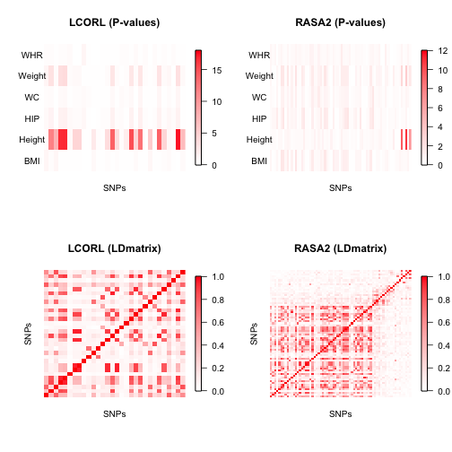

In the Figure, we draw image of $-\log_{10}$ transformed P-values for each SNP and trait. Gene *LCORL* was the most significant gene. As we can see from the Figure, there are many very significant SNPs for trait Height in Gene *LCORL*. No doubt MGAS and MTaSPUsSet identified this gene.

MGAS use extended Simes procedure so it considers top few p-values in their algorithm. Thus, MGAS works well with sparse signal such as *RASA2*. Since the signal is sparse, MTaSPUsSet detect this gene with larger $\gamma_1$ and $\gamma_2$. With ($\gamma_1, \gamma_2$) = (1,8), (2,8), (4,8) and (8,8), MTaSPUsSet P-values were less than 1e-7 with $10^7$ permutations.

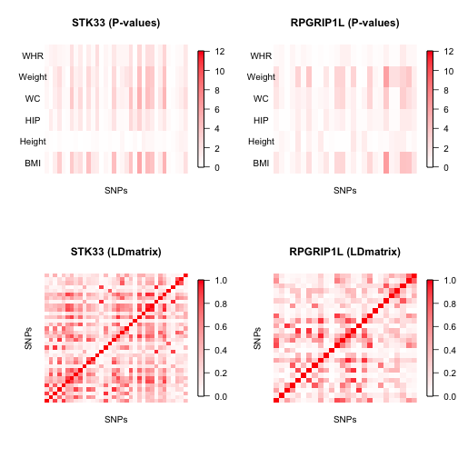